# Exemple de rendu

## Description de la données & de la problématique

### Problèmatique

Comment évoluent les métriques calculées de la richesse produites dans le monde au cours du temps, par pays, et par différentes méthodes. Pour cela je vais explorer les données qui sont présentées ci-dessous.

### Définition

Le Penn World Table est un jeu de données maintenu conjointement par des chercheurs de l’université de Californie à Davis et du Groeningen Growth Develpment Centre de l’université de Groningue pour mesurer le produit intérieur brut réel dont la parité de pouvoir d’achat en prenant en compte les revenues et la valeur monaitaire national au cours du temps et dans différents pays.

### Details

The Penn World Table provides purchasing power parity and national income accounts converted to international prices for 189 countries/territories for some or all of the years 1950–2010. The European Union or the OECD provide more detailed purchasing power and real product estimates for their countries and the World Bank makes current price estimates for most PWT countries at the GDP level.

This version contains data from PWT version 7.1. As far as possible the original data from PWT has been preserved. For example, percentages have been maintained rather than converted to fractions.

China is contained in two versions. For all details see the official documentation.

### Source

Alan Heston, Robert Summers and Bettina Aten, Penn World Table Version 7.1, Center for International Comparisons of Production, Income and Prices at the University of Pennsylvania, July 2012. URL http://pwt.econ.upenn.edu/.

## DATA MINING

```r
library("ggplot2")
library("maps")
library(dplyr)
library(pwt)
```

Nous allons utiliser les données de l’année de 2010 de la data.frame `pwt7.1` en utilisant la fonction filter() et les données du paquet “world” en chargeant les données avec la fonction `map_data`.

Nous allons fusioner les données des data.frame `map` des par leurs pays en une seule data.frame.

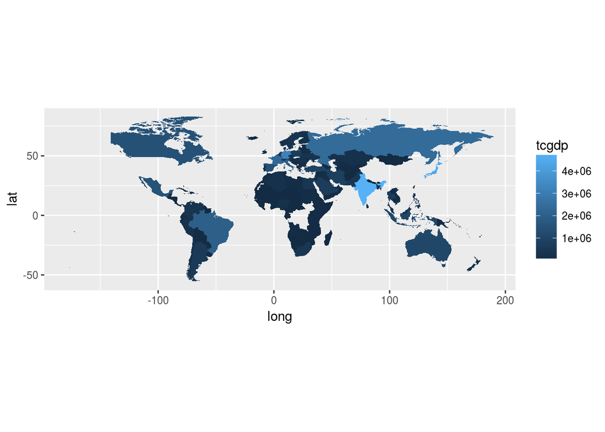

Les pays ne sont pas les mêmes voir ci-dessous, ce qui pose problème au précédent graphique.

```r
# base R
  df$country[!unique(df$country) %in% unique(map$region)]
```

```
##  [1] Antigua and Barbuda        China Version 1
##  [3] China Version 2            Congo, Democratic Republic
##  [5] Congo, Republic of         Cote d'Ivoire
##  [7] Gambia, The                Hong Kong
##  [9] Korea, Republic of         Macao
## [11] Micronesia, Fed. Sts.      Slovak Republic
## [13] St. Kitts & Nevis          St. Lucia
## [15] St. Vincent & Grenadines   Trinidad & Tobago
## [17] United Kingdom             United States of America
## 190 Levels: Afghanistan Albania Algeria Angola ... Zimbabwe
```

```r
# dplyr
  df %>% filter(  !unique(country) %in% unique(map$region))  %>%  select(country)
```

```
##                       country
## 1         Antigua and Barbuda
## 2             China Version 1
## 3             China Version 2
## 4  Congo, Democratic Republic
## 5          Congo, Republic of
## 6               Cote d'Ivoire
## 7                 Gambia, The
## 8                   Hong Kong
## 9          Korea, Republic of
## 10                      Macao
## 11      Micronesia, Fed. Sts.
## 12            Slovak Republic
## 13          St. Kitts & Nevis
## 14                  St. Lucia
## 15   St. Vincent & Grenadines
## 16          Trinidad & Tobago
## 17             United Kingdom
## 18   United States of America
```

On résoud ce problème en utilisant la convention isocode.

```r
#install.packages("countrycode")
library("countrycode")
map$iso3c =  countrycode(map$region, origin = "country.name","iso3c")
```

Nous allons refusionner les données précedents

Il y encore des pays qui sont absent l’Allemagne, la république du Cango, et la république démocratique du Cango. Nous devons pour résoudre ce bug changer le nom du pays “à la main” pour faire fonctionner notre programme.

## Visualisation

### Monde

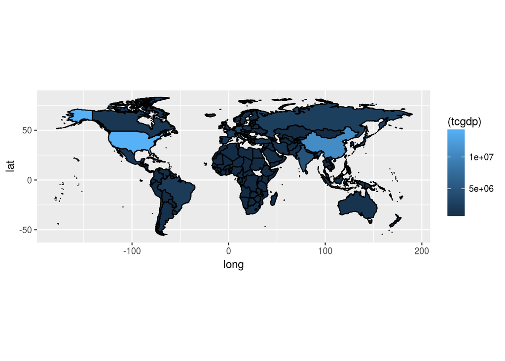

```r
p = ggplot(df.map, aes(x = long, y = lat, group = group, fill = (tcgdp)))
p + geom_polygon( color="black") +
  coord_quickmap()
```

### Par continents

Pour cela, il faut créer une autre variable “continent” à notre data.frame `df.map`, qu nous permettra de créer des panneaux différents en fonction du pays concerné.

```r
df.map$continent = countrycode(df.map$region,
                                 origin = "country.name", destination = "continent")
```

```r
library("dplyr")
df.map.2 = df.map %>%
  filter(!is.na(long)) %>%
  filter(!is.na(lat))
```

[figure not shown]

```r
df.map.2 = df.map.2 %>%
  group_by(continent) %>%
  filter(lat >= quantile(lat, probs = .01, names = FALSE)) %>%
  filter(lat < quantile(lat, probs = .99, names = FALSE)) %>%
  filter(long >= quantile(long, probs = .01, names = FALSE)) %>%
  filter(long < quantile(long, probs = .99, names = FALSE))
```